# Network analytics

# 1 Connecting to the database

The database is generated using a separate file. Initially it ran parallel calls to the `Rscript` command focusing on all NSF awards from the year 2000 onwards. The code is documented in the files `build_award_network` and `batch_run`. After visiting some more documentation about `neo4j` I switched to a new implementation, detailed in `writecsv.R`, and then the `cypher` file `load_csv.cql`. With these two files I was able to generate a much more robust implementation, even if it did still take a while on my laptop.

# 2 Data Model

[figure not shown]

The data model uses the [XML Schema for NSF awards](https://github.com/macks22/nsf-award-data/blob/master/docs/nsf-xml-schema-details.md) and is centered around the `award` node. The `award` node includes `AwardID`, `AwardTitle`, `AbstractNarration`, `AwardAmount`, `AARAAmount`, and `AwardInstrument`. `AwardEffectiveDate` and `AwardExpirationDate` are expressed as relationships with `Year` nodes. The same relationship occurs with `MinAmdLetterDate` and `MaxAmdLetterDate`.

# 3 Some Simple Stats

## 3.1 Unique Node Types

| nodes | Count | Nodes |
| --- | --- | --- |
| Award | 355176 | Award |
| Person | 179570 | Person |
| Institution | 16602 | Institution |
| Program | 10251 | Program |
| ProgramOfficer | 2685 | ProgramOfficer |
| Directorate | 464 | Directorate |
| Division | 114 | Division |
| Year | 80 | Year |
| State | 61 | State |
| Country | 55 | Country |
| Month | 13 | Month |

Duplicates may be identified, in part, through string matches (in particular for `award`), however, for other node types, such as `people`, matches are more difficult to determine, since an individual may both move institutions and share a name with another individual. Approaches at linking individuals across such moves, and with common names have been undertaken before, where proximity is determined not only by exact name matches, but also by matching networks of co-authors. In this project we are interested in analysis year by year and will disregard potential effects of unique `person` nodes.

## 3.2 Unique Relationship Types

Average PIs per grant on all grants, querying the database for all people linked to awards through a single link. I’ve added in the program constraint, because it lets us also assess differences between programs. Because an award might have multiple programs we need to output the awards, group by award ID, but also group by program.

| edges | count |
| --- | --- |
| Funded_by | 781458 |
| Referenced_by | 641464 |
| Awarded_to | 531351 |
| Year_Amended_Min | 355176 |
| Year_Started | 355176 |
| Handled | 355176 |
| Year_Expired | 355176 |
| Year_Amended_Max | 355176 |
| Administered_by | 355176 |
| Employed_by | 231734 |
| Program_of | 23911 |
| In_State | 16683 |
| Month_Expired | 702 |
| Month_Started | 623 |
| Month_Amended_Max | 616 |
| Month_Amended_Min | 585 |
| Within | 565 |
| In_Country | 124 |

Here we see that the links for `funded_by`, which link the `program` and the `award` have a much higher value than the number of awards. In principle we might expect that each award is funded by only a single `organization`, but in practice we find that many awards are funded by multiple organizations. Similarly, `awarded_to`, which links an `award` to `people` is also high, because it is again possible for a single award to have multiple awardees at a single institution. We begin to have fewer relationships per `award` nodes when we link `award` and `institution` with the `administered` relationship, and so on. This is all to say that the numbers of edges do not seem to indicate any large underlying problems with our model.

To ensure that we were able to follow paths accurately, we embedded the award number into each edge relationship using the `award` property. This means that for some edges (particularly those with few edges, such as `program_reference`) there are likely to be very many `award` elements, wheras, for those linking an `award` to a `person` there are likely to be few `award` elements in the `awarded_to` relationship.

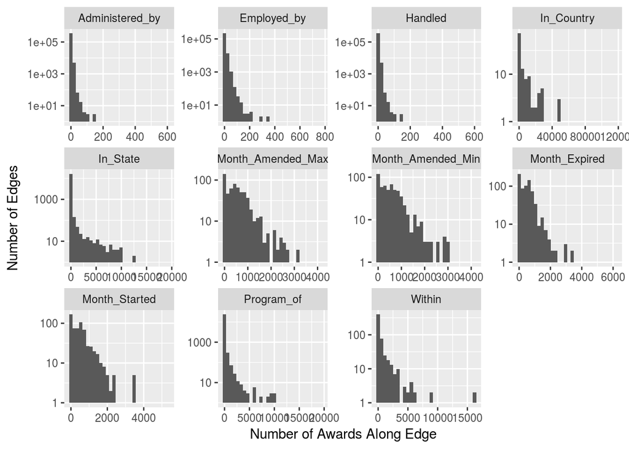

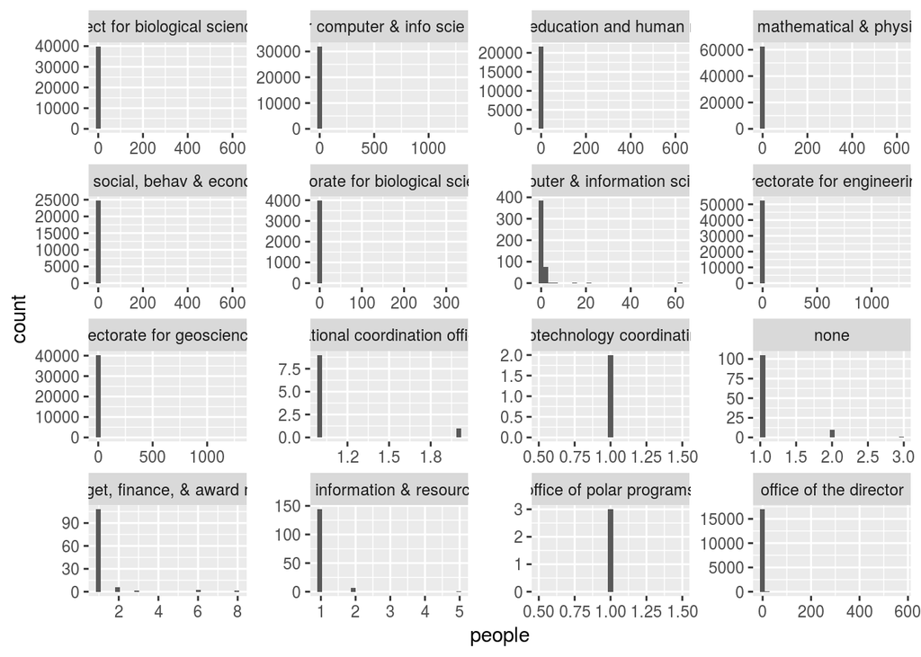

| directorate | mean | sd | count |
| --- | --- | --- | --- |
| direct for biological sciences | 1.66 | 4.23 | 39951 |
| direct for computer & info scie & enginr | 1.98 | 9.57 | 32001 |
| direct for education and human resources | 2.72 | 7.51 | 21750 |
| direct for mathematical & physical scien | 1.53 | 3.35 | 62568 |
| direct for social, behav & economic scie | 1.67 | 5.18 | 24723 |
| directorate for biological sciences | 1.43 | 7.34 | 3985 |
| directorate for computer & information science & engineering | 1.41 | 3.13 | 465 |
| directorate for engineering | 1.63 | 5.86 | 52276 |
| directorate for geosciences | 1.79 | 7.42 | 40348 |
| national coordination office | 1.10 | 0.32 | 10 |
| natl nanotechnology coordinating office | 1.00 | 0.00 | 2 |
| none | 1.10 | 0.33 | 116 |
| office of budget, finance, & award management | 1.21 | 0.94 | 118 |
| office of information & resource mgmt | 1.07 | 0.38 | 152 |
| office of polar programs | 1.00 | 0.00 | 3 |
| office of the director | 1.43 | 5.35 | 17028 |

# 4 The extent of duplicate grants

## 4.1 How many grants are duplicates?

One challenge is that different institutions submit subawards of the same proposal. We want to fid out, first, how many exact duplicates there are, how many are the same but with different capitalization or punctuation, and then a distribution of approximate matches for individual grants.

```r
all_titles <- RNeo4j::cypherToList(ec_graph,
                 "MATCH q = (p:Person)-[r]-(n:Award)-[s]-(o:Directorate)
                  RETURN n.AwardTitle AS title,
                         n.AwardAmount AS amount,
                         n.AwardInstrument AS instrument,
                         count(p) AS people") %>%
  map(as_data_frame) %>%
  bind_rows

count_table <- all_titles %>% group_by(people) %>% summarise(count = n())

colnames(count_table) <- c("Title Frequency", "Number of Awards")
knitr::kable(count_table)
```

| Title Frequency | Number of Awards |
| --- | --- |
| 1 | 238414 |
| 2 | 65450 |
| 3 | 19992 |
| 4 | 9356 |
| 5 | 9294 |
| 6 | 1152 |
| 7 | 366 |
| 8 | 187 |
| 9 | 69 |
| 10 | 60 |
| 11 | 29 |
| 12 | 24 |
| 13 | 14 |
| 14 | 19 |
| 15 | 10 |
| 16 | 9 |
| 17 | 9 |
| 18 | 6 |
| 19 | 4 |
| 20 | 9 |
| 21 | 9 |
| 22 | 5 |
| 23 | 3 |
| 24 | 1 |
| 25 | 3 |
| 26 | 3 |
| 27 | 4 |
| 28 | 1 |
| 29 | 1 |
| 30 | 1 |
| 32 | 1 |
| 36 | 1 |
| 38 | 3 |
| 41 | 2 |
| 43 | 1 |
| 44 | 1 |
| 45 | 1 |
| 47 | 2 |
| 48 | 1 |
| 52 | 1 |
| 54 | 2 |
| 55 | 1 |
| 59 | 1 |
| 66 | 1 |
| 71 | 1 |
| 74 | 1 |
| 81 | 1 |
| 94 | 1 |
| 95 | 1 |
| 102 | 1 |
| 106 | 1 |
| 110 | 1 |
| 118 | 1 |
| 125 | 1 |
| 134 | 1 |
| 150 | 1 |
| 210 | 1 |
| 306 | 1 |
| 319 | 1 |
| 397 | 1 |

So, we can see that there are definitely duplicate awards. It’s surprising to me (SJG) that there are so many single institution awards, but I’ve only ever been on multi-institution awards and so my experience may be atypical.

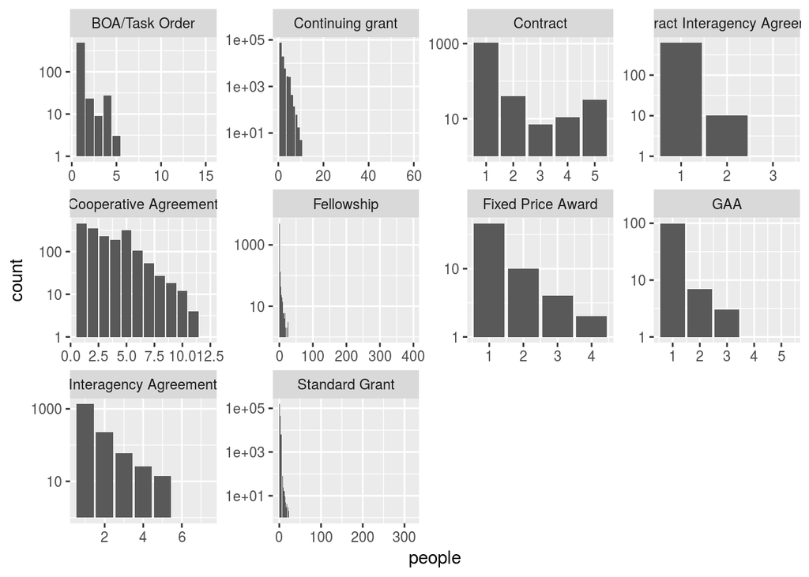

```r
count_table <- all_titles %>% group_by(people, instrument) %>% summarise(count = n())

count_table <- count_table %>% group_by(instrument) %>% filter(n() > 2)

ggplot(count_table, aes(x = people, y = count)) +
  geom_bar(stat = 'identity') +
  facet_wrap(~instrument, scales = 'free') +
  scale_y_log10()
```

This gives us a better sense, both of how often multi-institution grant occur, but also how that varies across Award Instrument.

## 4.2 Looking at Duplicates

So, lets start off by examining the grants with the most duplicate names.

```r
mass_award <- all_titles %>%
  mutate(title, low_title = tolower(title)) %>%
  group_by(low_title, instrument) %>%
  filter(n() > 5) %>% summarise(count=n()) %>%
  arrange(desc(count))

knitr::kable(mass_award)
```

| low_title | instrument | count |
| --- | --- | --- |
| undergraduate research participation | Standard Grant | 696 |
| pre-college teacher development in science | Standard Grant | 686 |
| graduate research fellowship program | Fellowship | 582 |
| doctoral dissertation research in anthropology | Standard Grant | 393 |
| student science training | Standard Grant | 384 |
| pre-college teacher development | Standard Grant | 306 |
| 1969 institutional grants for science | Standard Grant | 242 |
| presidential young investigator award | Continuing grant | 217 |
| shipboard scientific support equipment | Standard Grant | 216 |
| oceanographic instrumentation | Standard Grant | 210 |
| graduate research fellowship program (grfp) | Fellowship | 208 |
| instructional scientific equipment program | Standard Grant | 198 |
| support for nsf graduate fellows | Fellowship | 196 |
| graduate research fellowships support grant | Fellowship | 176 |
| student-originated studies | Standard Grant | 162 |
| student science training for high ability secondary school students | Standard Grant | 154 |
| doctoral dissertation research in systematic biology | Standard Grant | 152 |
| 1978 science faculty professional development program | Standard Grant | 125 |
| student science training program | Standard Grant | 125 |
| nato postdoctoral fellow | Fellowship | 124 |
| 1977 science faculty professional development program | Standard Grant | 118 |
| graduate research fellowships | Fellowship | 115 |
| doctoral dissertation research in geography and regional science | Standard Grant | 113 |
| comprehensive assistance to undergraduate science education | Standard Grant | 111 |
| support for national science foundation graduate fellows | Fellowship | 111 |
| graduate fellowship support grant | Fellowship | 107 |
| doctoral dissertation research in sociology | Standard Grant | 101 |
| fy 81 science faculty professional development program | Standard Grant | 95 |
| doctoral dissertation research in political science | Standard Grant | 92 |
| nsf-nato postdoctoral fellow | Fellowship | 86 |

[output cut: 604 more lines]

# 5 Average PIs per grant on EarthCube Grants

```r
ec_awards <- RNeo4j::cypherToList(ec_graph,
                           "match (p:Person)-[r]-(n:Award) WHERE n.AbstractNarration =~ '.*EarthCube.*'
                            RETURN n.AwardID, count(p) AS people")

award_summary <- data.frame(mean = ec_awards %>% map(function(x)x$people) %>% unlist %>% mean,
                            sd   = ec_awards %>% map(function(x)x$people) %>% unlist %>% sd)
```

## 5.1 All People by Year

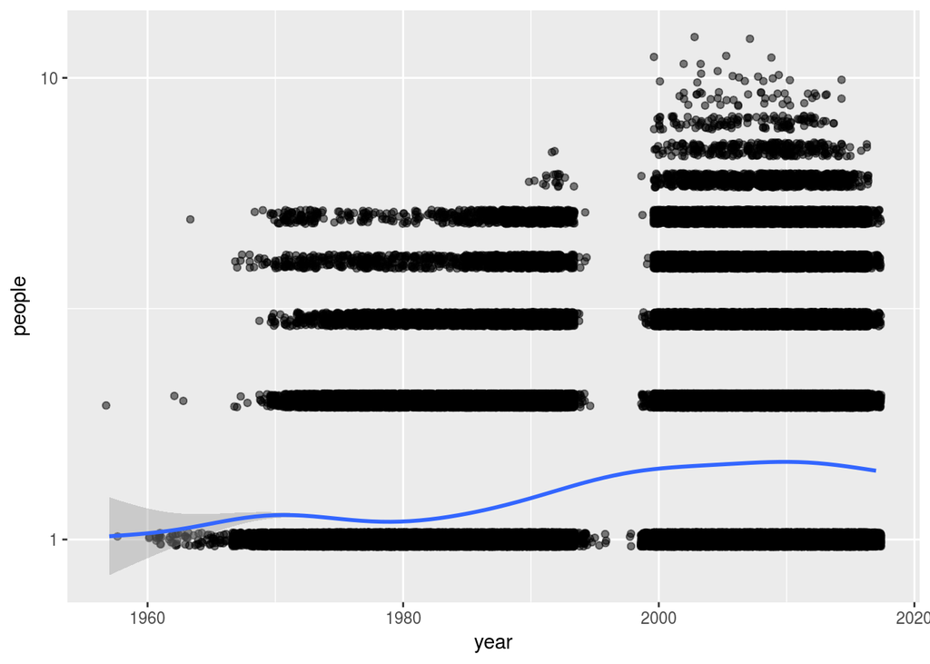

```r
  people_by_year <- RNeo4j::cypherToList(ec_graph,
                             "match (p:Person)-[r:Awarded_to]-(n:Award)-[ys:Year_Started]-(y:Year)
                              WHERE n.AwardID IN ys.AwardID AND y.Year > 1950 AND y.Year < 2018
                              RETURN n.AwardID AS award, y.Year AS year, count(p) AS people") %>%
  bind_rows

ggplot(people_by_year, aes(x = year, y = people)) +
  geom_jitter(alpha = 0.5) +
  geom_smooth(method = "gam", formula = y~ s(x)) +
  scale_y_log10()
```

All EarthCube Grants by Year:

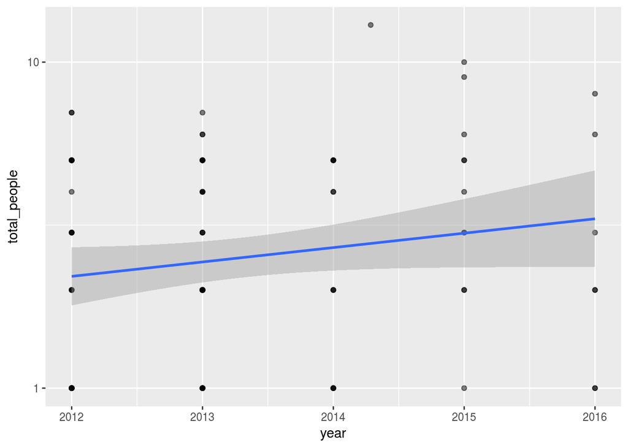

```r
  aa <- RNeo4j::cypherToList(ec_graph,
                             "match (p:Person)-[r:Awarded_to]-(n:Award)-[ys:Year_Started]-(y:Year)
                              WHERE n.AwardID IN ys.AwardID
                                    AND y.Year > 1950 AND y.Year < 2018
                                    AND n.AbstractNarration =~ '.*EarthCube.*'
                              RETURN n.AwardID AS award, n.AwardTitle as title,
                                     y.Year AS year, count(p) AS people") %>%
  bind_rows %>%
  group_by(title) %>%
  summarise(total_people = sum(people), year = mean(year))

ggplot(aa, aes(x = year, y = total_people)) +
  geom_point(alpha = 0.5) +
  geom_smooth(method = "gam", formula = y ~ x, se = TRUE) +
  scale_y_log10()
```

So there’s a shift, but the values in the NSF data have so many single PI grants it’s hard to really make much of it.

# 6 Diversity of Grant Networks

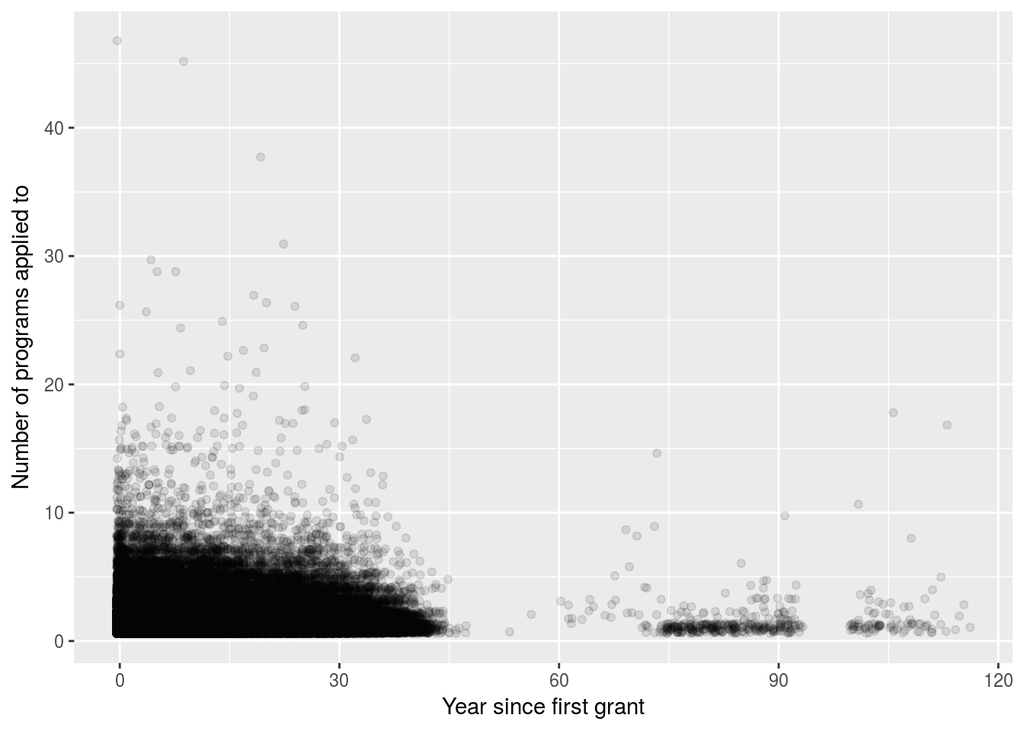

```r
pgm_per_yr <- RNeo4j::cypherToList(ec_graph,
                'MATCH (p:Person)<-[ap:Awarded_to]-(a:Award)-[ay:Year_Started]-(y:Year)
                 MATCH (a)-[apr:Funded_by]-(pr:Program)
                 WHERE a.AwardID IN apr.AwardID AND
                       a.AwardID IN ay.AwardID
                 WITH DISTINCT p as people,
                      y as year,
                      SIZE(COLLECT(DISTINCT pr.Text)) as program,
                      (CASE WHEN a.AbstractNarration =~ ".*EarthCube.*"
                            THEN 1 ELSE 0
                       END) AS earthcube
                 RETURN people.EmailAddress as EmailAddress,
                        people.LastName as LastName,
                        people.FirstName as FirstName,
                        year.Year as Year, program, earthcube;') %>%
  bind_rows()

# Then we clear everyone without an at symbol:
clean_per_yr <- pgm_per_yr %>% filter(grepl("@", EmailAddress))

zeroed_year <- clean_per_yr %>%
  group_by(EmailAddress) %>%
  mutate(career_year = Year - min(Year), total_years = max(Year) - min(Year)) %>%
  arrange(EmailAddress, career_year) %>% filter(total_years > 0)

# That last filter kills about 80k people.

ggplot(zeroed_year) +
  geom_jitter(aes(x = career_year, y = program), alpha = 0.1) +
  xlab("Year since first grant") +
  ylab("Number of programs applied to")
```

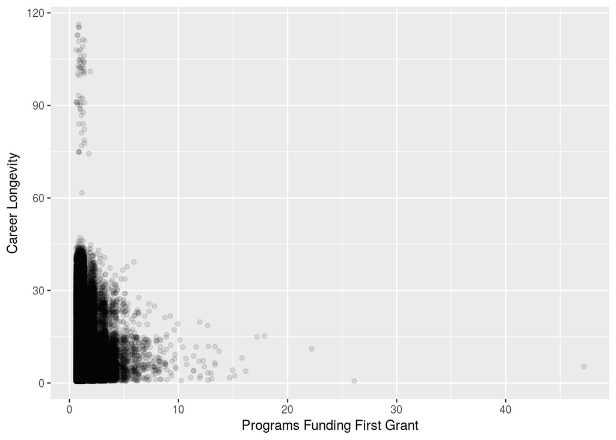

```r
ggplot(zeroed_year %>% filter(career_year == 0)) +
  geom_jitter(aes(x = program, y = total_years), alpha = 0.1) +
  xlab("Programs Funding First Grant") +
  ylab("Career Longevity")
```